# R Data Science 1

Sanghoo Yoon

2019년 9월 25일

## 학교 알리미 자료 처리

[figure not shown]

학교 알리미

- 사이트의 공시정보 > 학사학생 > 학교기본정보를 선택 시 학교현황을 다운 받을 수 있습니다.
- csv 파일로 자료를 다운 받아 2019년 현황을 간단히 분석해보겠습니다.
- 학교기본정보(2019)를 다운 받아 R에서 불러오면 아래와 같습니다.
- 자료가 잘 불러와졌는지 head()함수를 통해 확인할 수 있습니다.
- dim()함수를 통해 행과 열의 수를 추가로 확인하실 수 있습니다.

```r
data <- read.csv("F:/work/R-work/2019/KERIS/day2/2019년_공시대상학교정보(전체).csv")
head(data)
```

```
##         시도교육청                   지역교육청              지역
## 1 서울특별시교육청 서울특별시강남서초교육지원청 서울특별시 서초구
## 2 서울특별시교육청     서울특별시중부교육지원청 서울특별시 종로구
## 3 서울특별시교육청 서울특별시강남서초교육지원청 서울특별시 강남구
## 4 서울특별시교육청 서울특별시강남서초교육지원청 서울특별시 강남구
## 5 서울특별시교육청 서울특별시강남서초교육지원청 서울특별시 강남구
## 6 서울특별시교육청 서울특별시강남서초교육지원청 서울특별시 강남구
##   정보공시.학교코드                         학교명 학교급코드 설립구분
## 1        S000003511     서울교육대학교부설초등학교          2     국립
## 2        S000003563 서울대학교사범대학부설초등학교          2     국립
## 3        S010000738               서울개일초등학교          2     공립
## 4        S010000741               서울구룡초등학교          2     공립
## 5        S010000742               서울논현초등학교          2     공립
## 6        S010000743               서울대곡초등학교          2     공립
##   학교특성 분교여부 설립유형 주야구분 개교기념일   설립일 법정동코드
```

[output cut: 34 more lines]

- 만약 시도교육청 별로 관리하는 학교의 수가 궁금한 경우에는
- table 함수와 ggplot2 패키지의 qplot을 통해 시각화 할 수 있습니다.

```r
# table 함수로 시도교육청 현황 파악
 table(data$시도교육청)
```

```
##
##         강원도교육청         경기도교육청       경상남도교육청
##                  674                 2471                  994
##       경상북도교육청     광주광역시교육청     대구광역시교육청
##                  983                  324                  461
##     대전광역시교육청     부산광역시교육청     서울특별시교육청
##                  311                  639                 1361
## 세종특별자치시교육청     울산광역시교육청     인천광역시교육청
##                   91                  250                  537
##       전라남도교육청       전라북도교육청 제주특별자치도교육청
##                  875                  778                  198
##       충청남도교육청       충청북도교육청
##                  739                  497
```

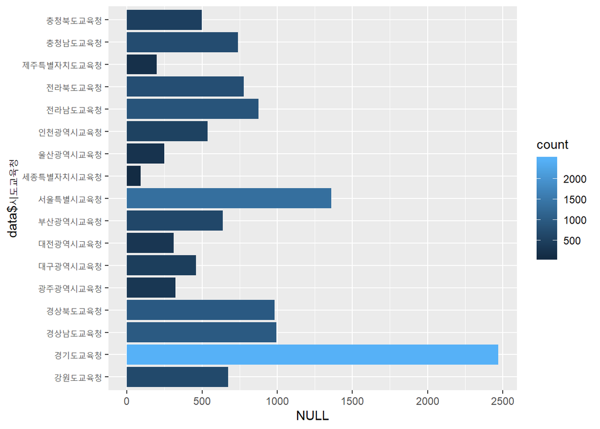

```r
library(ggplot2)
 qplot(data$시도교육청, fill=..count..)+coord_flip()
```

- 이 자료는 보시다시피 전국 자료입니다.
- 대구광역시 교육청에서 관리하는 자료만 선택하고 싶다면,,
- 또 대구광역시 내 사립학교만 선택하여 분석하고 싶다면…

```r
data.daegu <- data[data$시도교육청=="대구광역시교육청"&data$설립구분=="사립",]
tail(data.daegu)
```

```
##            시도교육청       지역교육청            지역 정보공시.학교코드
## 2450 대구광역시교육청 대구광역시교육청 대구광역시 남구        S030001358
## 2451 대구광역시교육청 대구광역시교육청 대구광역시 남구        S030001359
## 2452 대구광역시교육청 대구광역시교육청 대구광역시 남구        S030001360
## 2453 대구광역시교육청 대구광역시교육청 대구광역시 남구        S030001427
## 2454 대구광역시교육청 대구광역시교육청 대구광역시 동구        S030001428
## 2455 대구광역시교육청 대구광역시교육청 대구광역시 남구        S030001573
##            학교명 학교급코드 설립구분 학교특성 분교여부 설립유형 주야구분
## 2450 대구광명학교          5     사립                 N     단설     주간
## 2451 대구보명학교          5     사립                 N     단설     주간
## 2452 대구덕희학교          5     사립                 N     단설     주간
## 2453 대구보건학교          5     사립                 N     단설     주간
## 2454 대구선명학교          5     사립                 N     단설     주간
## 2455 대구영화학교          5     사립                 N     단설     주간
##      개교기념일   설립일 법정동코드                  주소내역
```

[output cut: 34 more lines]

```r
# 대구광역시 교육청 자료만 선택되었는지 시각적으로 확인해보자..
library(raster)
```

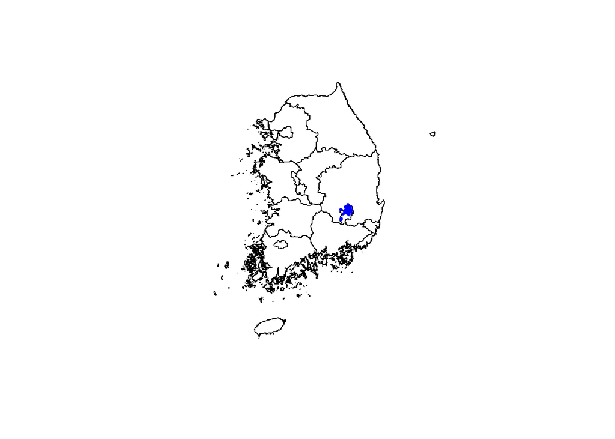

```r
kor <- raster::getData("GADM", country="KOR", level=1)

plot(kor)
points(data.daegu$경도, data.daegu$위도, pch=16, col="blue", cex=0.5)
```

- 지도의 좌표에 이상이 있어 살짝 밀리긴 했지만 대구광역시교육청의 사립학교만 선택 가능하다.
- 이 자료는 학교의 기본정보만 포함되어 있어 학생수, 교직원수, 학교용지 현황 등이 제공되지 않는다.
- 추가 분석을 위해선 해당파일을 다운 받아 끼워넣기를 해야한다.

### 본 수업은 이러한 자료효율적으로 처리하기 위한 기본 R 사용법을 배운다.

- 정규표현식(*) -고급과정 을 배우면 원하는 단어만 추출하여 분석을 진행할 수 있어요.

```r
library(stringr)
s1<-which(str_detect(data.daegu$학교명,"초등학교"))
s1
```

```
## [1] 1 2 3 4
```

```r
s2<-which(str_detect(data.daegu$학교명,"중학교"))
s2
```

```
##  [1]  5  6  7  8  9 10 11 12 13 14 15 16 17 18 19 20 21 22 23 24 25 26 27
## [24] 28 29 30 31 32 33 34 35 36 37 38
```

```r
s3<-which(str_detect(data.daegu$학교명,"고등학교"))
s3
```

```
##  [1] 39 40 41 42 43 44 45 46 47 48 49 50 51 52 53 54 55 56 57 58 59 60 61
## [24] 62 63 64 65 66 67 68 69 70 71 72 73 74 75 76 77 78 79 80 81 82 83 84
## [47] 85 86 87
```

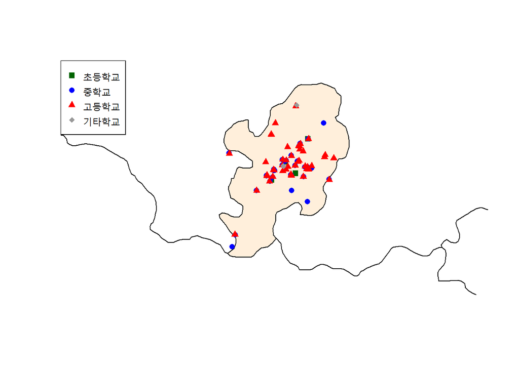

```r
primary.school <- data.daegu[s1,]
middle.school <- data.daegu[s2,]
high.school <- data.daegu[s3,]
etc.school <- data.daegu[-c(s1,s2,s3),]

col1 <- ifelse(kor@data$NAME_1=="Daegu","antiquewhite1",NA)
plot(kor, xlim=c(128.45,128.65), ylim=c(35.5,36), col=col1) #대구광역시만 다른 색으로 표현

points(primary.school$경도, primary.school$위도-0.08, pch=15, col="darkgreen", cex=1)
points(middle.school$경도, middle.school$위도-0.08, pch=16, col="blue", cex=1)
points(high.school$경도, high.school$위도-0.08, pch=17, col="red", cex=1)
points(etc.school$경도, etc.school$위도-0.08, pch=18, col="grey60", cex=1)

legend("topleft", pch=15:18, col=c("darkgreen","blue","red","grey60"),
       legend=c("초등학교","중학교","고등학교","기타학교"))
```